# Part II - The impact of the loans caractéristics on the number of investors and percent funded

## by (Dakhouche Salah Eddine)

## Investigation Overview

In this investigation, I wanted to look at the characteristics of loans that could have an impact on the number of investors and the percent funded. The main focus was on the estimated return, the prosper score, the income range and the loan original amount.

## Dataset Overview

The data set contain 113937 records of loans and 82 columns, i choosed 10 columns that I consider that they could have the most impact of the two varialbes

## The distribution of Percent Funded

This variable was an important one in our analysis but unfortunately, the majority of loans are fully funded and the correlation with other variables is so low that makes this variable unexploitable.

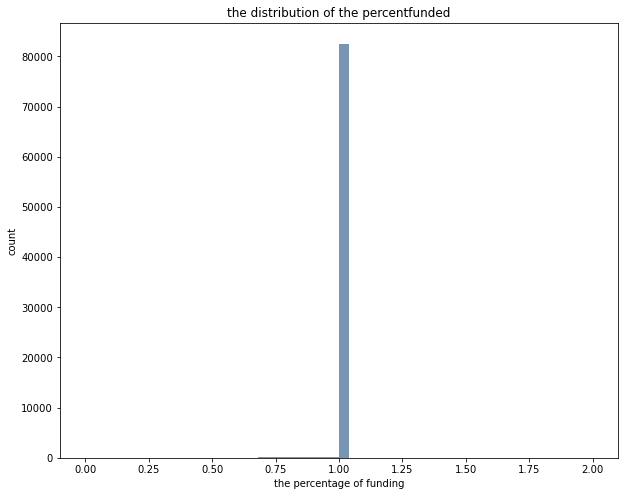

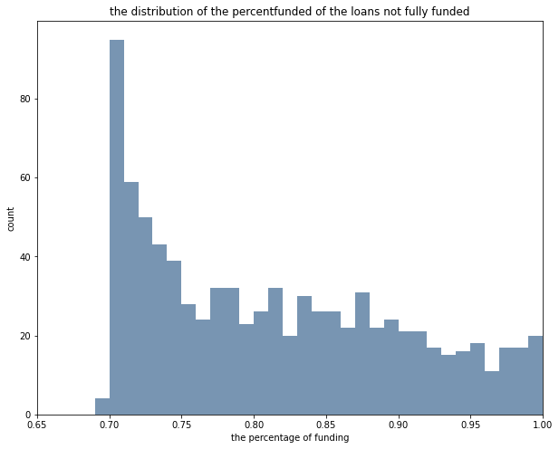

## the distribution of the number of investors on each loan

The number of investors has a peak of 1 investor which means that a lot of loans are funded by 1 investor and start to decrease. but with a log transformation, we can see another peak between 30 and 300.

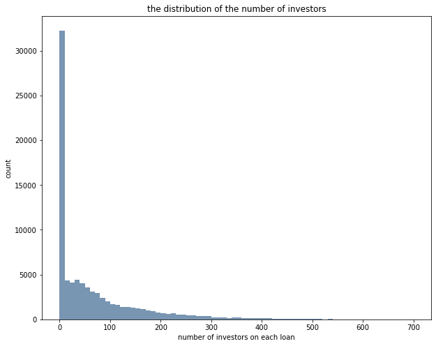

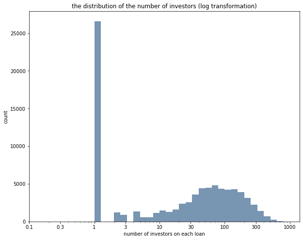

this variable represents the estimated risk of the loans, the higher the score the lower the risk. we can see a normal distribution of the risk scores

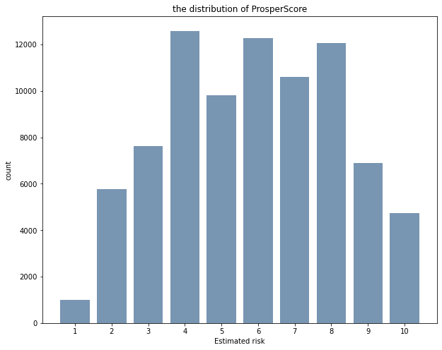

## Distribution of the Estimated return

We can see that the distribution of the estimated return variable can be considered normal with a peak of 9% and the range is between 1% and 23%

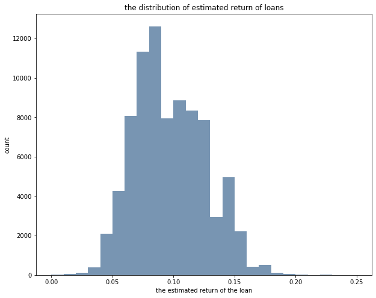

## Distribution of the Income range

The majority of borrowers have an income range between 25000 and 75000 and in second place are the borrowers with incomes of 75000 +

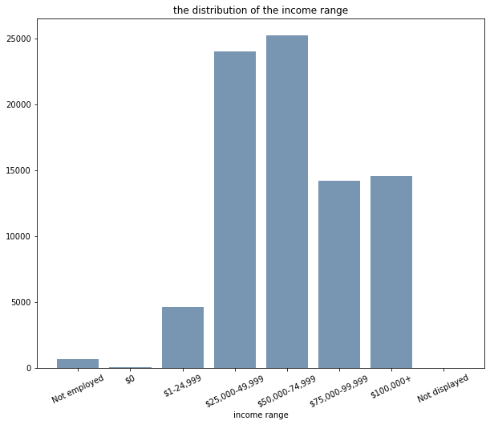

## Investors vs proser risk and Investors vs income range

ther is a positive relation between the number of investors and risk scores, the higher the prosper score the higher the number of investors

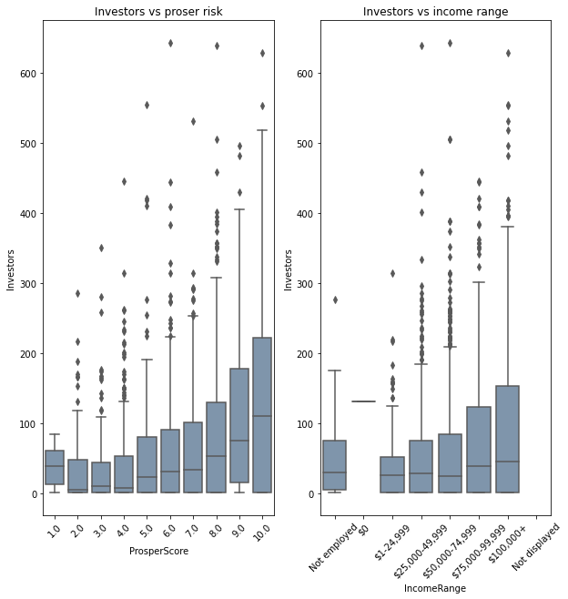

## investors vs LoanOriginal amount

I found that the higher the amount the higher the investors, which means that investors are not willing to put too much money into loans with higher amounts.

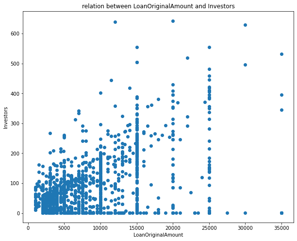

## Investors vs Loan original amount vs prosper score

I found that loans with low amount are safer and have low number of investors

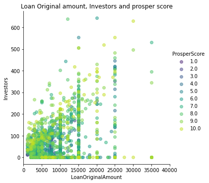

## Investors vs Loan original amount vs Income Range

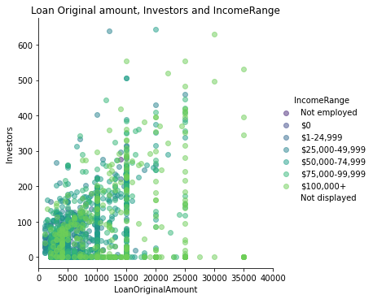